fossil

# GABi, dug back up.

Its data, its code and Figs 2 to 5 are back.

Read the code analysis

## Fig. 2

Structure-dependent biclustering algorithm recovery scores: best overlap per dataset, 40 synthetic datasets per structure.

Partly agreesRerun on random data

Published

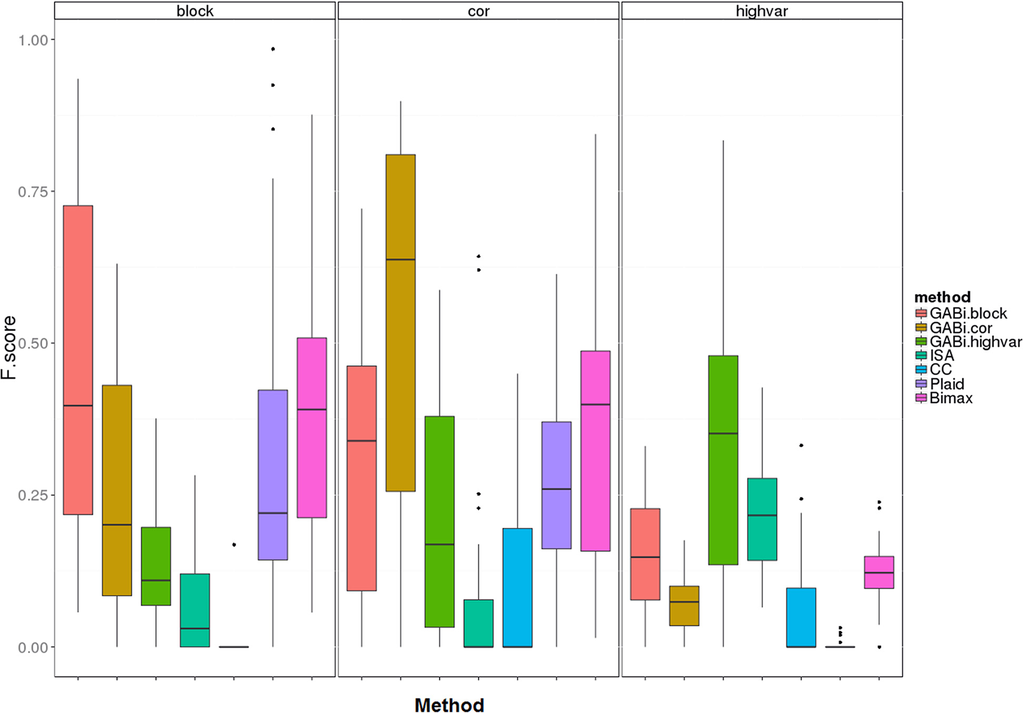

Reproduction in ggplot2

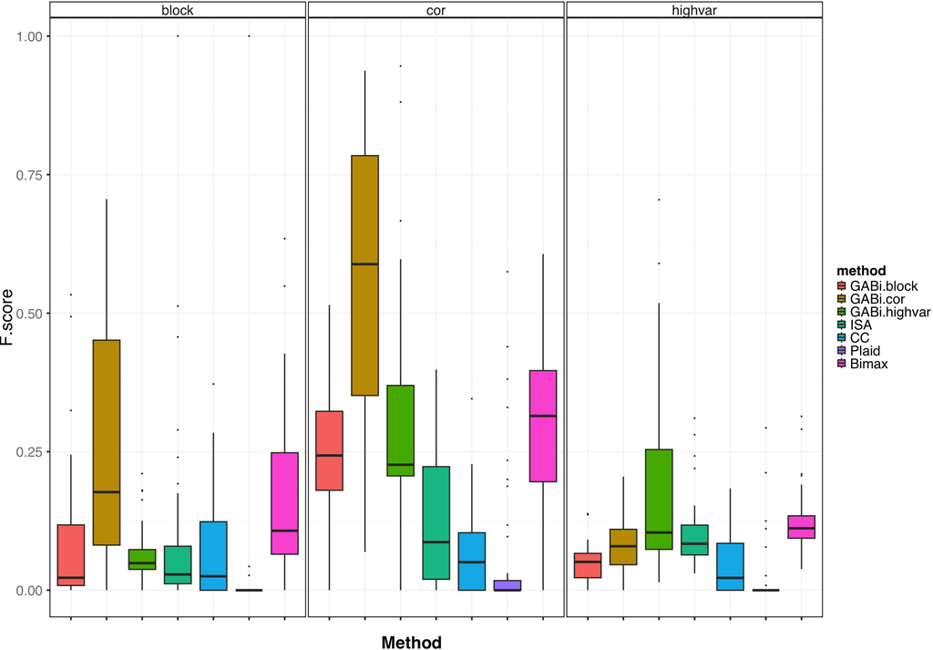

**Pixel size**

1946 × 1355

**Drawn at**

ggplot2, 1946×1355 px at 300 dpi

**Frame scale**

1.000 × 1.000

**Paper ink ≤2 px from ours**

51.9%

**Our ink ≤2 px from paper**

76.1%

**Mean |Δ| grey**

15.24

Rerun of the benchmark: 40 new datasets per structure from Algorithm 2 (n = 100, m = 20, p ~ U{1..100}, q ~ U{2..18}, ζ ~ U(0,1)). GABi 0.1 is run with the S1 fitness functions and its defaults; the paper does not report consistency, ρ or α, so we use 0.8, 0.5 and 0.05. ISA (isa2), CC, Plaid and Bimax (biclust 2.0.3.1) run with package defaults, also unreported in the paper. The datasets are random, so boxes are compared by their statistics below, not by pixels. The matched GABi model has the highest median for cor, but not for block (GABi.cor highest), highvar (Bimax highest). On block data, Algorithm 2’s offset b ~ N(0, 1) is negative in 21 of 40 datasets, where the implanted block is lower than the rest of its rows and the block model cannot see it: GABi.block’s median F is 0.01 there and 0.15 where b > 0. With consistency 0.6 instead of 0.8 the median rises to 0.16.

## Fig. 2 in numbers

Median and interquartile range per method. Published values are read from the figure’s box positions (fig2_measure.py, ±0.002 F.score). Highest median per structure: block: paper GABi.block, ours GABi.cor; cor: paper GABi.cor, ours GABi.cor; highvar: paper GABi.highvar, ours Bimax.

Read from the published pixels

[output not shown]

The paper (p. 11) reports that the matched GABi model beat every other method at p < 0.01 (Wilcoxon signed rank), except Bimax on block structure (p = 0.1). Our one-sided paired tests on the rerun:

| Structure | Comparison | p |
| --- | --- | --- |
| block | GABi.block > GABi.cor | 1 |
| block | GABi.block > GABi.highvar | 0.6 |
| block | GABi.block > ISA | 0.5 |
| block | GABi.block > CC | 0.43 |
| block | GABi.block > Plaid | 3.9e-07 |
| block | GABi.block > Bimax | 1 |
| cor | GABi.cor > GABi.block | 6.9e-08 |
| cor | GABi.cor > GABi.highvar | 6.2e-04 |
| cor | GABi.cor > ISA | 9.1e-13 |
| cor | GABi.cor > CC | 5.0e-11 |
| cor | GABi.cor > Plaid | 9.1e-13 |
| cor | GABi.cor > Bimax | 2.5e-06 |
| highvar | GABi.highvar > GABi.block | 2.9e-09 |
| highvar | GABi.highvar > GABi.cor | 4.0e-04 |
| highvar | GABi.highvar > ISA | 1.1e-04 |
| highvar | GABi.highvar > CC | 1.6e-06 |
| highvar | GABi.highvar > Plaid | 9.1e-13 |
| highvar | GABi.highvar > Bimax | 0.027 |

## Fig. 3

Pair-wise correlation of CpG methylation levels: bicluster samples (solid) and control set (dashed).

Partly agreesReconstructed from public data

Published

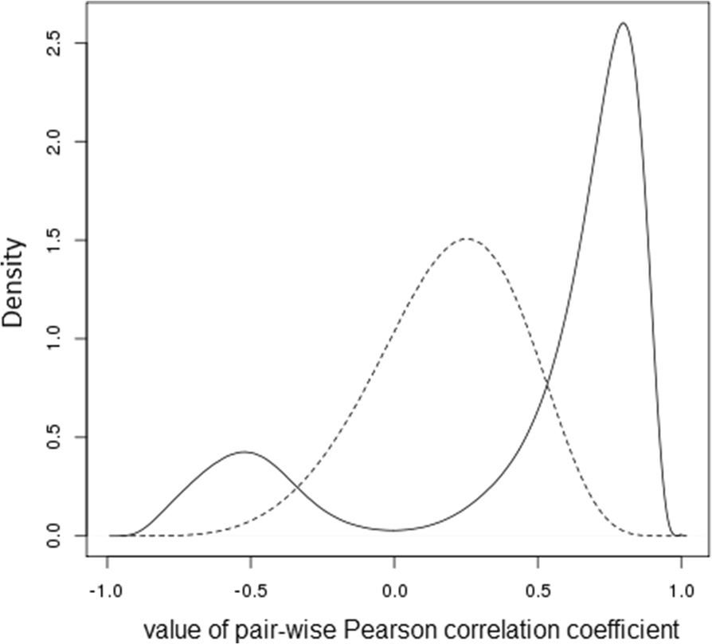

Reproduction in R base graphics

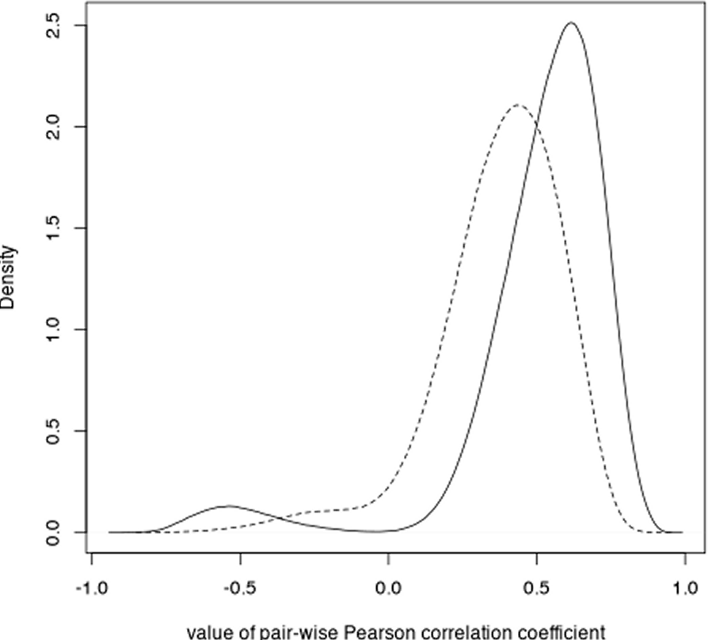

**Pixel size**

894 × 808

**Drawn at**

png() 480×480 px, 72 dpi

**Frame scale**

2.000 × 2.000

**Paper ink ≤2 px from ours**

8.9%

**Our ink ≤2 px from paper**

8.9%

**Mean |Δ| grey**

6.54

TCGA OV HumanMethylation27 (UCSC Xena), 146 bicluster and 146 control tumours found by GABi 0.1 with S1’s dysregulation-vs-outcome model on the Table S3 probes; 3,682 CpG sites selected. Paper: 21 and 21 tumours, 14,382 sites. Mode of the pair-wise correlations: 0.62 (bicluster), 0.43 (control).

## Fig. 4

Progression-free survival of the bicluster samples (solid) and the control set (dashed), TCGA.

DiffersReconstructed from public data

Published

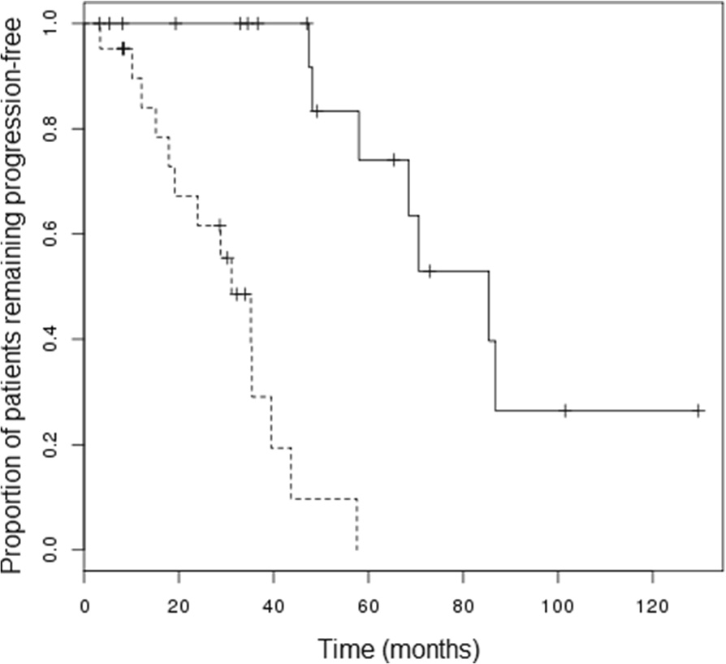

Reproduction in R base graphics

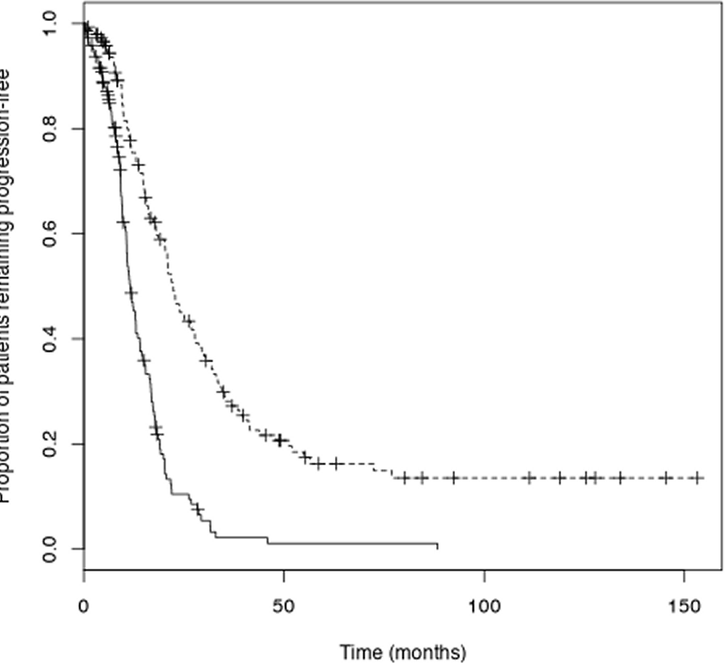

**Pixel size**

894 × 818

**Drawn at**

png() 480×480 px, 72 dpi

**Frame scale**

2.014 × 2.015

**Paper ink ≤2 px from ours**

2.2%

**Our ink ≤2 px from paper**

2.9%

**Mean |Δ| grey**

6.69

Same reconstruction. Logrank p = 3.0e-14 (paper 1 × 10⁻⁵). Median progression-free interval 11.5 vs 22.3 months (paper 85.4 vs 32). Our bicluster progresses sooner than its control set, the reverse of the paper. Progression-free interval from the TCGA Pan-Cancer clinical resource, not the 2013 portal data the paper used.

## Fig. 5

Progression-free survival of the validation cohort: most (solid) and least (dashed) correlated tumours.

AgreesIdentical data

Published

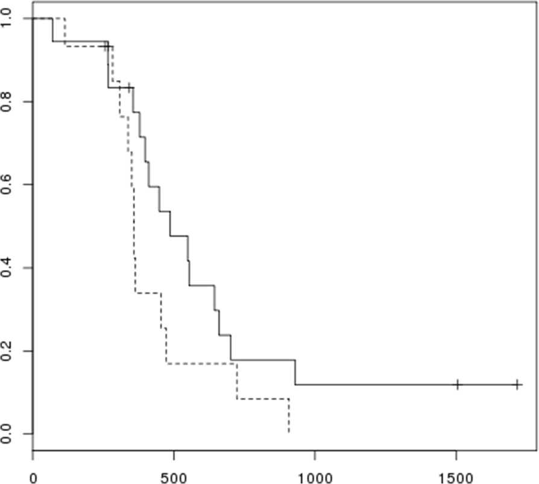

Reproduction in R base graphics

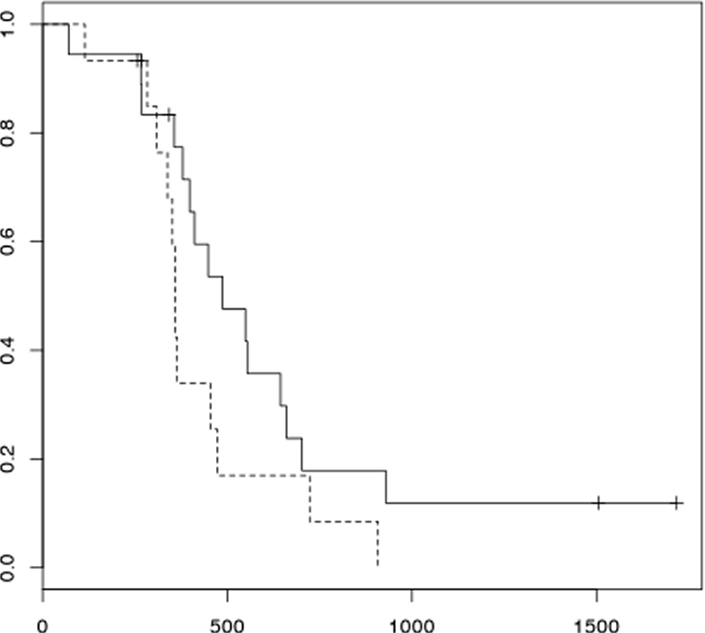

**Pixel size**

894 × 803

**Drawn at**

png() 480×480 px, 72 dpi

**Frame scale**

2.139 × 2.142

**Paper ink ≤2 px from ours**

100%

**Our ink ≤2 px from paper**

100%

**Mean |Δ| grey**

0.87

Same data as the paper: the clinical rows of Table S3 (20 + 20 patients, PFS in the file’s units). Logrank p = 0.12 for progression-free survival and 0.12 for overall survival; the paper reports 0.15 and 0.1.

## Tables S2 and S3 list different CpG sites

Our finding

Both are described as the 14,382 CpG sites of the dysregulation bicluster. They share 8,904. Both lists are sorted, and they agree row for row up to row 520. After that they drift apart by up to 46 positions, which looks like an indexing slip in one of them.

| Probes (TCGA OV HM27, 584 primary tumours) | Mean \|r\| between probes | Median SD of β |
| --- | --- | --- |
| In both lists (8,904) | 0.243 | 0.018 |
| Only in Table S3 (5,478) | 0.270 | 0.018 |
| Only in Table S2 (5,478) | 0.101 | 0.153 |
| Random probes in neither list (3,000) | 0.098 | 0.133 |

The probes only in Table S3 behave like the shared ones: tightly co-varying, with low variance across tumours. The probes only in Table S2 behave like random probes. Table S3’s row labels also match its values (mean β per row against the TCGA mean of the labelled probe: r = 0.996; against the S2 probe at the same row: r = 0.010). We take Table S3’s list as the bicluster’s CpG sites.

## What came back

**Fig. 5 data**

Table S3 is the validation cohort of Fig. 5, not the TCGA set: its 40 columns are the 20 tumours most (Group1, solid) and 20 least (Group2, dashed) correlated with the bicluster profile, and its times span the figure’s unlabelled 0 to 1700 axis. Kaplan-Meier curves from it match the published curves pixel for pixel. Logrank p = 0.12 (progression-free) and 0.12 (overall); the paper prints 0.15 and 0.1.

**How Figs 3 to 5 were drawn**

R base graphics on the default png() device (480×480 px, 72 dpi, pointsize 12, default margins), cropped to the plot frame and enlarged 2.00×, 2.01× and 2.14×. The survival curves use xaxs = "S", the survival 2.x default.

**How Fig. 2 was drawn**

ggplot2 with 0.9.3 theme sizes at a base of 8.6 pt, the default hue palette in method order, one facet per structure. Its box statistics are read back from the pixels (Fig. 2 in numbers, above).

**The bicluster’s CpG sites**

Table S3’s 14,382 row labels. Table S2 claims the same sites, but only 8,904 agree; from row 521 on it is shifted by up to 46 positions, and its extra probes behave like random probes.

**What the code computes**

As published, S1’s dysregulation fitness cannot score a 21-sample bicluster in current R. Spearman’s test returns p = 0 for the seed row against itself and for |ρ| between 0.836 and 0.865, and GABi turns the resulting infinite score into 0. We add the 2e-16 floor that S1’s own selection function uses. Details, and 77 checks of GABi 0.1 and S1 against the paper, are on the implementation page.

**TCGA bicluster (Figs 3 and 4)**

146 bicluster and 146 control tumours with 3,682 CpG sites (paper: 21, 21 and 14,382); progression-free logrank p = 3.0e-14 (paper 1 × 10⁻⁵). The paper does not list the tumours, so they are found again by GABi on public TCGA data.

## What stayed buried

- GABi’s thresholds (consistency, ρ, α), the comparison methods’ settings and the synthetic datasets of Fig. 2
- The identities of the 21 + 21 TCGA tumours
- The 2013 TCGA clinical data

Figs 2 to 4 can therefore match the paper only in distribution, not pixel for pixel.

## What we matched

Figs 3 to 5 are base R graphics and Fig. 2 is ggplot2. We drew each one with the same tools and mapped it onto the published figure’s pixel grid using its plot frame alone. The curves inside the frame are compared, not fitted.

**Figs 3 to 5 device**

Each published frame is exactly the plot region of R’s default png() device: 480×480 px at 72 dpi, pointsize 12, default margins, giving 391×347.5 px. The images are cropped to that frame and enlarged 2.00× (Fig. 3), 2.01× (Fig. 4) and 2.14× (Fig. 5). We draw on that device and enlarge by the same frame-to-frame scale with bicubic resampling.

**Survival curves**

plot(survfit(...), lty = c(1, 2), mark.time = TRUE) with xaxs = "S", the survival 2.x default (the axis starts at 0). survival 3 changed the default to “r”.

**Fig. 2 theme**

The published text widths fit ggplot2 0.9.3’s theme sizes at a base of 8.6 pt: axis titles at 8.6 pt, tick labels, strips and legend at 0.8× that. The theme has white strips and panels with black borders, grey50 tick labels, no x tick labels and a bold “Method”. Tick length, legend key size and gaps were measured in pixels.

**Alignment**

One scale and offset per axis, taken from the frame lines (the facet grid in Fig. 2). Nothing inside the frame is used for fitting.

**Reading the views**

Overlay: ink is the paper only, light green is the reproduction only, dark green is both. Difference: darker means a larger grey-level difference (×2). Mean |Δ| includes JPEG artefacts in the published images.

## The session

Session not recorded: no log of the agent session was kept for this reproduction.